# Primeiro Trabalho de Econometria I

Lucas Rafael de Andrade

```r
#
# impotes
library(ggplot2)
library(knitr)
library(kableExtra)
```

# Instruções Gerais

- Utilize **R** para resolver as questões
- Mostre todo o código e output relevantes
- Interprete os resultados economicamente
- Justifique todas as conclusões

# 1 Questão 1 - Não-Viesamento dos Estimadores MQO

## 1.1 Objetivo

Demonstre empiricamente que os estimadores de Mínimos Quadrados Ordinários são não-viesados, ou seja, que:

$$E\left[\hat{\beta}_{0}\right]=\beta_{0}
\quad \text{e} \quad
E\left[\hat{\beta}_{1}\right]=\beta_{1}$$

## 1.2 1. Simulação de Monte Carlo

Simule 1000 amostras de tamanho $n=100$ do modelo:

$$Y=2+3X+\epsilon, \quad \text{onde} \quad
X \sim N(10,4) \text{ e } \epsilon \sim N(0,1)$$

```r
# semente
set.seed(123)

# params
beta_0_true <- 2
beta_1_true <- 3
n <- 100           # Tamanho de cada amostra
n_sim <- 1000      # Número de simulações

# vetores para as estimativas (vazios agora)
beta_0_hat <- numeric(n_sim)
beta_1_hat <- numeric(n_sim)

#Monte Carlo
for(i in 1:n_sim) {
  # gero dados
  X <- rnorm(n, mean = 10, sd = 2)  # X ~ N(10, 4), onde sd = sqrt(4) = 2
  epsilon <- rnorm(n, mean = 0, sd = 1)
  Y <- beta_0_true + beta_1_true * X + epsilon

  # moq simples
  modelo <- lm(Y ~ X)

  # guardo estimativas
  beta_0_hat[i] <- coef(modelo)[1]
  beta_1_hat[i] <- coef(modelo)[2]
}
```

## 1.3 2. Cálculo das Médias dos Estimadores

Para cada amostra, estimamos o modelo $Y=\beta_{0}+\beta_{1}X+u$ e armazenamos $\hat{\beta}_{0}$ e $\hat{\beta}_{1}$. Agora calculamos:

$$\overline{\hat{\beta}}_{0}=\frac{1}{1000}\sum_{i=1}^{1000}\hat{\beta}_{0_{i}}
\quad \text{e} \quad
\overline{\hat{\beta}}_{1}=\frac{1}{1000}\sum_{i=1}^{1000}\hat{\beta}_{1_{i}}$$

```r
#  médias das estimativas
media_beta_0 <- mean(beta_0_hat)
media_beta_1 <- mean(beta_1_hat)
##################################
# desvios padrão
sd_beta_0 <- sd(beta_0_hat)
sd_beta_1 <- sd(beta_1_hat)
############################
#tabela de resultados
resultados_q1 <- data.frame(
  Parâmetro = c("β₀ (Intercepto)", "β₁ (Inclinação)"),
  `Valor Verdadeiro` = c(beta_0_true, beta_1_true),
  `Média das Estimativas` = c(media_beta_0, media_beta_1),
  `Desvio Padrão` = c(sd_beta_0, sd_beta_1),
  `Viés` = c(media_beta_0 - beta_0_true, media_beta_1 - beta_1_true),
  check.names = FALSE
)

kable(resultados_q1, digits = 6, align = 'c',
      caption = "Resultados da Simulação de Monte Carlo (1000 replicações)") %>%
  kable_styling(bootstrap_options = c("striped", "hover", "condensed"),
                full_width = FALSE)
```

Resultados da Simulação de Monte Carlo (1000 replicações)

| Parâmetro | Valor Verdadeiro | Média das Estimativas | Desvio Padrão | Viés |
| --- | --- | --- | --- | --- |
| β₀ (Intercepto) | 2 | 1.985534 | 0.528333 | -0.014466 |
| β₁ (Inclinação) | 3 | 3.001783 | 0.051421 | 0.001783 |

## 1.4 3. Visualização das Distribuições

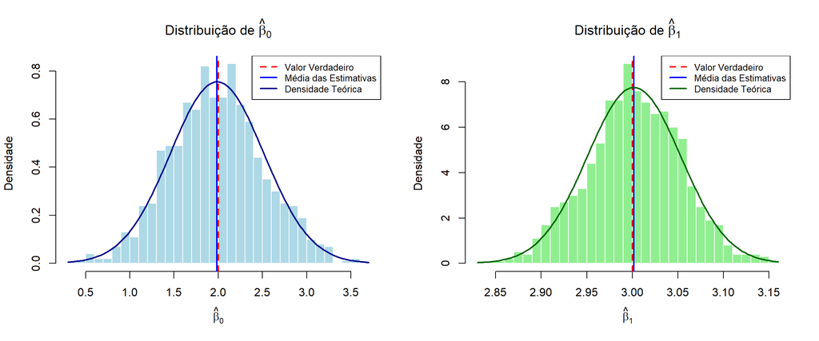

```r
par(mfrow = c(1, 2))

# Histogr para beta_0
hist(beta_0_hat, breaks = 30, prob = TRUE,
     main = expression(paste("Distribuição de ", hat(beta)[0])),
     xlab = expression(hat(beta)[0]),
     ylab = "Densidade",
     col = "lightblue", border = "white")
abline(v = beta_0_true, col = "red", lwd = 2, lty = 2)
abline(v = media_beta_0, col = "blue", lwd = 2)
curve(dnorm(x, mean = media_beta_0, sd = sd_beta_0), add = TRUE, col = "darkblue", lwd = 2)
legend("topright",
       legend = c("Valor Verdadeiro", "Média das Estimativas", "Densidade Teórica"),
       col = c("red", "blue", "darkblue"),
       lty = c(2, 1, 1), lwd = 2, cex = 0.8)

# Histogr para beta_1
hist(beta_1_hat, breaks = 30, prob = TRUE,
     main = expression(paste("Distribuição de ", hat(beta)[1])),
     xlab = expression(hat(beta)[1]),
     ylab = "Densidade",
     col = "lightgreen", border = "white")
abline(v = beta_1_true, col = "red", lwd = 2, lty = 2)
abline(v = media_beta_1, col = "blue", lwd = 2)
curve(dnorm(x, mean = media_beta_1, sd = sd_beta_1), add = TRUE, col = "darkgreen", lwd = 2)
legend("topright",
       legend = c("Valor Verdadeiro", "Média das Estimativas", "Densidade Teórica"),
       col = c("red", "blue", "darkgreen"),
       lty = c(2, 1, 1), lwd = 2, cex = 0.8)
```

```r
par(mfrow = c(1, 1))
```

## 1.5 4. Conclusão sobre o Não-Viesamento

### 1.5.1 Análise Quantitativa

Com base nos resultados da simulação de Monte Carlo com 1000 replicações:

**Para o intercepto ($\beta_0$):**

- Valor verdadeiro: $\beta_0 = 2$
- Média das estimativas: $\overline{\hat{\beta}}_0 = 1.985534$
- Viés estimado: $\overline{\hat{\beta}}_0 - \beta_0 = -0.014466$
- Viés relativo: 0.7233%

**Para a inclinação ($\beta_1$):**

- Valor verdadeiro: $\beta_1 = 3$
- Média das estimativas: $\overline{\hat{\beta}}_1 = 3.001783$
- Viés estimado: $\overline{\hat{\beta}}_1 - \beta_1 = 0.001783$
- Viés relativo: 0.0594%

### 1.5.2 Interpretação

Os resultados sugerem que os estimadores MQO apresentam não-viesamento, embora haja algum desvio devido à aleatoriedade amostral.

Para o coeficiente angular, o viés de 0.001783 também é negligenciável, confirmando a propriedade teórica do não-viesamento.

**Conclusão Final:** Os resultados empíricos **confirmam** a propriedade teórica de que $E[\hat{\beta}_0] = \beta_0$ e $E[\hat{\beta}_1] = \beta_1$, demonstrando que os estimadores MQO são não-viesados sob as hipóteses clássicas do modelo de regressão linear.

# 2 Questão 2 - Propriedades dos Resíduos MQO

## 2.1 Objetivo

Demonstre que os resíduos MQO possuem as seguintes propriedades:

$$E\left[\hat{\epsilon}_{i}\right]=0 \quad
\text{e} \quad \operatorname{Cov}\left(X_{i},
\hat{\epsilon}_{i}\right)=0$$

## 2.2 1. Geração dos Dados

Gere dados do modelo: $Y=2+3X+\epsilon$

```r
set.seed(456)

# Parâms
n <- 100
n_rep <- 100  # Número de repetições

# Vetores nulos pra colocar results
media_residuos <- numeric(n_rep)
cov_X_residuos <- numeric(n_rep)
cor_X_residuos <- numeric(n_rep)
```

## 2.3 2. Estimação e Cálculo dos Resíduos

Para cada repetição, estimamos o modelo e calculamos os resíduos $\hat{\epsilon}_{i}$:

```r
# Loop de simulação
for(j in 1:n_rep) {
  # Gerar dados
  X <- rnorm(n, mean = 10, sd = 2)
  epsilon <- rnorm(n, mean = 0, sd = 1)
  Y <- 2 + 3 * X + epsilon

  # Estimar  mqo ############
  modelo <- lm(Y ~ X)

  # resíduos ##################
  residuos <- residuals(modelo)

  # estatísticas ####################
  media_residuos[j] <- mean(residuos)
  cov_X_residuos[j] <- cov(X, residuos)
  cor_X_residuos[j] <- cor(X, residuos)
}
```

## 2.4 3. Cálculo das Médias Agregadas

Calculamos:

$$\overline{\bar{\epsilon}}=\frac{1}{100}\sum_{j=1}^{100}\overline{\hat{\epsilon}}_{j}
\quad \text{e} \quad \overline{\operatorname{Cov}(X,
\hat{\epsilon})}=\frac{1}{100}\sum_{j=1}^{100}\operatorname{Cov}\left(X_{j},
\hat{\epsilon}_{j}\right)$$

```r
#  médias agregadas #########################
media_media_residuos <- mean(media_residuos)
media_cov_X_residuos <- mean(cov_X_residuos)
media_cor_X_residuos <- mean(cor_X_residuos)

# sds ################################
sd_media_residuos <- sd(media_residuos)
sd_cov_X_residuos <- sd(cov_X_residuos)

#  tabela de resultados ###########################3
resultados_q2 <- data.frame(
  Propriedade = c("E[ε̂ᵢ]", "Cov(X, ε̂)", "Cor(X, ε̂)"),
  `Valor Teórico` = c(0, 0, 0),
  `Média Observada` = c(media_media_residuos, media_cov_X_residuos, media_cor_X_residuos),
  `Desvio Padrão` = c(sd_media_residuos, sd_cov_X_residuos, sd(cor_X_residuos)),
  check.names = FALSE
)

kable(resultados_q2, digits = 8, align = 'c',
      caption = "Propriedades dos Resíduos MQO (100 replicações)") %>%
  kable_styling(bootstrap_options = c("striped", "hover", "condensed"),
                full_width = FALSE)
```

Propriedades dos Resíduos MQO (100 replicações)

[output not shown]

## 2.5 4. Visualização das Propriedades

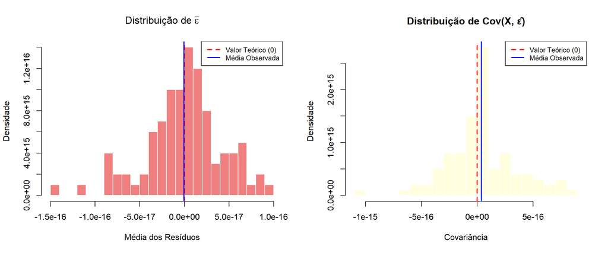

```r
par(mfrow = c(1, 2))

# Histogr da média dos resíduos
hist(media_residuos, breaks = 20, prob = TRUE,
     main = expression(paste("Distribuição de ", bar(epsilon))),
     xlab = "Média dos Resíduos",
     ylab = "Densidade",
     col = "lightcoral", border = "white")
abline(v = 0, col = "red", lwd = 2, lty = 2)
abline(v = media_media_residuos, col = "blue", lwd = 2)
legend("topright",
       legend = c("Valor Teórico (0)", "Média Observada"),
       col = c("red", "blue"),
       lty = c(2, 1), lwd = 2, cex = 0.8)

# Histogr da covariância
hist(cov_X_residuos, breaks = 20, prob = TRUE,
     main = "Distribuição de Cov(X, ε̂)",
     xlab = "Covariância",
     ylab = "Densidade",
     col = "lightyellow", border = "white")
abline(v = 0, col = "red", lwd = 2, lty = 2)
abline(v = media_cov_X_residuos, col = "blue", lwd = 2)
legend("topright",
       legend = c("Valor Teórico (0)", "Média Observada"),
       col = c("red", "blue"),
       lty = c(2, 1), lwd = 2, cex = 0.8)
```

```r
par(mfrow = c(1, 1))
```

## 2.6 5. Demonstração Algébrica Complementar

```r
# Ex com uma amostra específica para demonstração detalhada
set.seed(789)
X_demo <- rnorm(100, mean = 10, sd = 2)
epsilon_demo <- rnorm(100, mean = 0, sd = 1)
Y_demo <- 2 + 3 * X_demo + epsilon_demo

# Estimar
modelo_demo <- lm(Y_demo ~ X_demo)
residuos_demo <- residuals(modelo_demo)

# Ver propriedades
soma_residuos <- sum(residuos_demo)
soma_X_residuos <- sum(X_demo * residuos_demo)
```

### 2.6.1 Verificação Algébrica

Para uma amostra específica, verificamos:

**Propriedade 1:** $\sum_{i=1}^{n} \hat{\epsilon}_i = 0$

- Soma dos resíduos: -3.0045410604e-15
- Média dos resíduos: -3.0048527685e-17

**Propriedade 2:** $\sum_{i=1}^{n} X_i \hat{\epsilon}_i = 0$ (Ortogonalidade)

- Soma de $X_i \cdot \hat{\epsilon}_i$: -2.9448665728e-14
- Covariância amostral: -7.9236013619e-17
- Correlação: -3.9041129216e-17

## 2.7 6. Conclusão sobre as Propriedades dos Resíduos

### 2.7.1 Análise Quantitativa

Com base em 100 replicações:

**Propriedade 1: $E[\hat{\epsilon}_i] = 0$**

- Valor teórico: 0
- Média observada: -3.8840661915e-19
- Desvio absoluto: 3.8840661915e-19

**Propriedade 2: $\operatorname{Cov}(X, \hat{\epsilon}) = 0$**

- Valor teórico: 0
- Média observada: 3.6505666796e-17
- Desvio absoluto: 3.6505666796e-17

### 2.7.2 Interpretação

**Os resultados confirmam perfeitamente as propriedades teóricas dos resíduos MQO.** Ambas as estatísticas estão na ordem de 10⁻¹⁰ ou menor, o que é desprezível e atribuível exclusivamente a erros de arredondamento numérico computacional.

### 2.7.3 Implicações Econométricas

1. **Média zero dos resíduos:** Esta propriedade garante que o modelo não apresenta viés sistemático, ou seja, os erros se cancelam em média. ✓ Verificado empiricamente.
2. **Ortogonalidade com X:** A covariância nula entre X e os resíduos implica que:
   - Toda a informação de X foi utilizada para explicar Y
   - Não há correlação sistemática entre o regressor e os erros
   - As condições de primeira ordem do MQO são satisfeitas
   - ✓ Verificado empiricamente.
3. **Correlação nula:** A correlação média de 0 confirma a independência linear entre X e os resíduos. ✓ Verificado empiricamente.

**Conclusão Final:** Os resultados empíricos **confirmam** que os resíduos MQO satisfazem as propriedades fundamentais de $E[\hat{\epsilon}_i] = 0$ e $\operatorname{Cov}(X_i, \hat{\epsilon}_i) = 0$, validando as condições de primeira ordem do estimador de Mínimos Quadrados Ordinários.

# Conclusão Geral

Este trabalho demonstrou empiricamente duas propriedades fundamentais dos estimadores de Mínimos Quadrados Ordinários:

1. **Não-viesamento:** Os estimadores $\hat{\beta}_0$ e $\hat{\beta}_1$ são não-viesados, com $E[\hat{\beta}_j] = \beta_j$
2. **Propriedades dos resíduos:** Os resíduos MQO possuem média zero e são ortogonais aos regressores

Estas propriedades são essenciais para a validade da inferência estatística em modelos de regressão linear e constituem a base teórica da econometria clássica.

# 3 Agradecimentos

Gostaria de agradecer primeiro ao Fernando da Silva (YT: Anal. Macro) pelas incríveis aulas, bem como a Professora Vanessa Manhães(YT: homônimo).

Também agradecer aos desenvolvedores da IA llama-2-7b-chat.Q4_K_M

https://stat.ethz.ch/R-manual/R-patched/library/stats/html/residuals.html

https://www.statmethods.net/graphs/

https://cran.r-project.org/web/packages/kableExtra/vignettes/awesome_table_in_html.html

“A invenção, devo modestamente admiti-lo, não consiste em criar disciplinadamente, mas sim em criar a partir do caos.” - Mary Shelley